# NycFlights13

Dipta Dutta

20 November 2017

Exploring NYCFlights data This dataset is about all the flights leaving from NYC (i.e. JFK, LGA or EWR) in 2013.

```r
library(nycflights13)
library(tidyr)
library(dplyr)
library(rmarkdown)
library(Hmisc)
```

```r
library(maps)
library(corrplot)
help(package = "nycflights13")

dim(flights)
```

```
## [1] 336776     19
```

```r
View(flights)

glimpse(flights)
```

```
## Observations: 336,776
## Variables: 19
## $ year           <int> 2013, 2013, 2013, 2013, 2013, 2013, 2013, 2013,...
## $ month          <int> 1, 1, 1, 1, 1, 1, 1, 1, 1, 1, 1, 1, 1, 1, 1, 1,...
## $ day            <int> 1, 1, 1, 1, 1, 1, 1, 1, 1, 1, 1, 1, 1, 1, 1, 1,...
## $ dep_time       <int> 517, 533, 542, 544, 554, 554, 555, 557, 557, 55...
## $ sched_dep_time <int> 515, 529, 540, 545, 600, 558, 600, 600, 600, 60...
## $ dep_delay      <dbl> 2, 4, 2, -1, -6, -4, -5, -3, -3, -2, -2, -2, -2...
## $ arr_time       <int> 830, 850, 923, 1004, 812, 740, 913, 709, 838, 7...
## $ sched_arr_time <int> 819, 830, 850, 1022, 837, 728, 854, 723, 846, 7...
## $ arr_delay      <dbl> 11, 20, 33, -18, -25, 12, 19, -14, -8, 8, -2, -...
## $ carrier        <chr> "UA", "UA", "AA", "B6", "DL", "UA", "B6", "EV",...
## $ flight         <int> 1545, 1714, 1141, 725, 461, 1696, 507, 5708, 79...
## $ tailnum        <chr> "N14228", "N24211", "N619AA", "N804JB", "N668DN...
## $ origin         <chr> "EWR", "LGA", "JFK", "JFK", "LGA", "EWR", "EWR"...
## $ dest           <chr> "IAH", "IAH", "MIA", "BQN", "ATL", "ORD", "FLL"...
## $ air_time       <dbl> 227, 227, 160, 183, 116, 150, 158, 53, 140, 138...
## $ distance       <dbl> 1400, 1416, 1089, 1576, 762, 719, 1065, 229, 94...
## $ hour           <dbl> 5, 5, 5, 5, 6, 5, 6, 6, 6, 6, 6, 6, 6, 6, 6, 5,...
## $ minute         <dbl> 15, 29, 40, 45, 0, 58, 0, 0, 0, 0, 0, 0, 0, 0, ...
## $ time_hour      <dttm> 2013-01-01 05:00:00, 2013-01-01 05:00:00, 2013...
```

Flights are often delayed Performing explorartory Analysis will give some important questions to be answered

1. what was the Worst day to fly put of NYC in 2013

For that we need to find out the Total Delay = Avg Arrival Delay + Avg Departure Delay

loading the flights data

```r
flights %>%
  select(month, day, arr_delay, dep_delay) %>%
  filter(arr_delay >= 0, dep_delay >= 0) %>%
  group_by(month, day) %>%
  summarise(avg_delay =  mean(arr_delay, na.rm = TRUE) +
              mean(dep_delay, na.rm = TRUE)) %>%
  ungroup() %>%
  arrange(-avg_delay)
```

```
## # A tibble: 365 x 3
##    month   day avg_delay
##    <int> <int>     <dbl>
##  1     9    12  228.8011
##  2     9     2  223.1130
##  3     7    10  220.1812
##  4     4    10  217.2589
##  5     7    22  209.8665
##  6     3     8  209.1633
##  7     5    23  197.5820
##  8     6    24  197.0659
##  9    12     5  194.9683
## 10     7    28  190.2995
## # ... with 355 more rows
```

So we can see that September 12th is the worst day to fly out from NewYork where averagae delay was around 228 minutes

Next is we want to know is there any any particular airport where the delay happened

```r
dataflights = flights %>%
  select(origin,month,day,arr_delay,dep_delay) %>%
  filter(arr_delay >=0 , dep_delay >=0) %>%
  group_by(origin,month,day) %>%
  summarise(avg_delay =  mean(arr_delay, na.rm = TRUE) +
              mean(dep_delay, na.rm = TRUE)) %>%
  ungroup() %>%
  arrange(-avg_delay)

dataflights
```

```
## # A tibble: 1,095 x 4
##    origin month   day avg_delay
##     <chr> <int> <int>     <dbl>
##  1    LGA     9     2  305.4351
##  2    LGA     9    12  252.3333
##  3    EWR     9    12  244.4733
##  4    EWR     3     8  243.7569
##  5    LGA     4    10  241.9775
##  6    LGA     3     8  238.5699
##  7    LGA    12     5  233.2303
##  8    JFK     7    10  232.2164
##  9    LGA     6    24  228.2917
## 10    JFK     4    10  225.8091
## # ... with 1,085 more rows
```

As we can see the Flights originating from LGA at september 2 has the highest delay following by LGA and EWR at spetember 12th

Next we want to know total delay per Origin and plot it

```r
sumorigin = dataflights %>%
  group_by(origin) %>%
  summarise(TotalDelay=sum(avg_delay)) %>%
  ungroup() %>%
  arrange(-TotalDelay)
sumorigin
```

```
## # A tibble: 3 x 2
##   origin TotalDelay
##    <chr>      <dbl>
## 1    EWR   31781.34
## 2    LGA   31757.11
## 3    JFK   30921.52
```

We can see the the maximum flights originited from EWR are delayed

Next we are going to create a variable speed for the carriers

```r
SpeedDta=flights %>%
  mutate(speed = distance/air_time * 60) %>%
  group_by(carrier) %>%
  summarise(AvgSpeed = mean(speed,na.rm = T)) %>%
  ungroup() %>%
  arrange(-AvgSpeed)
SpeedDta
```

```
## # A tibble: 16 x 2
##    carrier AvgSpeed
##      <chr>    <dbl>
##  1      HA 480.3577
##  2      VX 446.1749
##  3      AS 443.6789
##  4      F9 425.1721
##  5      UA 420.8838
##  6      DL 418.4628
##  7      AA 417.4727
##  8      WN 400.5320
##  9      B6 399.9715
## 10      FL 394.3581
## 11      MQ 368.4028
## 12      OO 366.3201
## 13      EV 362.9436
## 14      9E 345.4304
## 15      US 341.9397
## 16      YV 331.9700
```

So we can see the fastest carrier is HA

next we want to know is there any seasonal patterns for the delay

Creating the ‘date’ variable by passing the entire data object inside a ‘with’ function. The ‘ISOdate’ function merges the ‘month’ & ‘day’ column along with year = 2013 to make a complete date column. We save this entire column in the ‘dataflights’ object.

```r
dataflights$date <- with(dataflights, ISOdate(year = 2013, month, day))
```

Creating a ggplot function with x-axis = Date and y-axis = Average delay

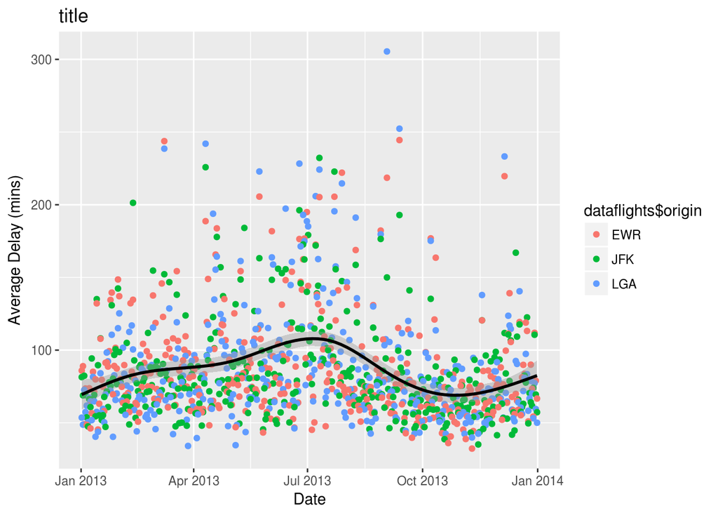

```r
ggplot(dataflights, aes(x = dataflights$date, y = dataflights$avg_delay, title = "Seasonality Trends")) + geom_point(aes(color = dataflights$origin))+ xlab("Date") + ylab("Average Delay (mins)") + geom_smooth(color = "Black")
```

This shows us that there is a PEAK in delays during June, July & August month and the delays generally fall down during the winter months October, November, December & January

On a day we want to know which particular time the delay occur in general ,we will need to have a plot the average delays per hour in all days across 2013. This will give us an hourly trend (if any) in the data.

```r
arr_delay_data <- flights %>%
  select(arr_delay, dep_delay, hour)
```

arr_delay_data[arr_delay_data$hour==24,] Making sure that 24:00 hrs is 00:00 hrs. Replacing all instances of 2400 hrs as 0000hrs. This will help us in making sure we have only 24 hours when we round off the hours to the nearest hour interval

```r
arr_delay_data$hour <- ifelse(arr_delay_data$hour == 2400, 0, arr_delay_data$hour)
```

to get a summarized dataset with average arrival delay for each hour.

```r
arr_delay <- arr_delay_data %>%
  filter(arr_delay >= 0, dep_delay >= 0) %>%
  select(hour, arr_delay, dep_delay) %>%
  group_by(hour) %>%
  summarise(avg_delay = mean(arr_delay, na.rm = TRUE) +
              mean(dep_delay, na.rm = TRUE)) %>%
  na.omit()
arr_delay
```

```
## # A tibble: 19 x 2
##     hour avg_delay
##    <dbl>     <dbl>
##  1     5  43.88715
##  2     6  63.30244
##  3     7  65.39650
##  4     8  75.25623
##  5     9  75.23592
##  6    10  82.69606
##  7    11  82.07464
##  8    12  79.66687
##  9    13  84.10898
## 10    14  93.52126
## 11    15  96.66818
## 12    16 108.83998
## 13    17 113.01397
## 14    18 112.45817
## 15    19 121.11031
## 16    20 115.84938
## 17    21 111.65876
## 18    22  98.27505
## 19    23  81.72683
```

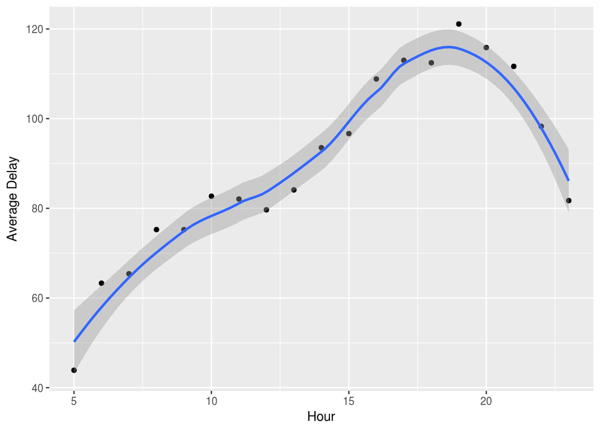

```r
ggplot(arr_delay,aes(x = as.numeric(hour),y = avg_delay),title = "Daily Hourly") + geom_point(color = "Black") + geom_smooth() + xlab("Hour") + ylab("Average Delay")
```

we can see that the flights starting around 15 - 20 have the maximum delays

Flights are often delayed due to weather condition so our next analysis will be on how weather affects the NYC flights

```r
flights = flights
weather = weather

#creating 'hours' column and making sure that hours are only from
#00:00 hrs to 23:00 hrs which is exactly as the 'weather' data set has.
#this will help us join the 2 data sets properly.
flights$hour <- ifelse(flights$hour == 24, 0, flights$hour)
#creating 'hours' column and making sure that hours are only from
#00:00 hrs to 23:00 hrs which is exactly as the 'weather' data set has.
#this will help us join the 2 data sets properly.
flights$hour <- ifelse(flights$hour == 24, 0, flights$hour)

#JOining the 'flights' and 'weather' datasets based on unique identifiers.
flights_weather <- left_join(flights, weather)
```

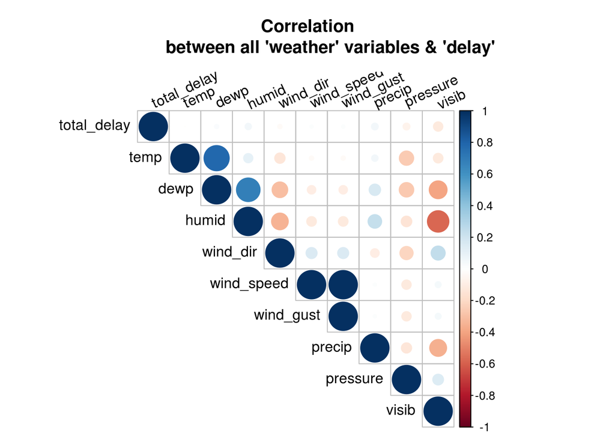

```r
#We create a 'delays' column that is addition of all the delays in
#arrival and departure (Consider only positive delays. Reason stated in
#1st problem solution)
flights_weather$arr_delay = ifelse(flights_weather$arr_delay >= 0,
                                    flights_weather$arr_delay, 0)
flights_weather$dep_delay = ifelse(flights_weather$dep_delay >= 0,
                                    flights_weather$dep_delay, 0)
flights_weather$total_delay = flights_weather$arr_delay + flights_weather$dep_delay


#creating a data with only delay and weather columns. Removing origin, date/time
#because we want a correlation between delay and the particular weather condition.
cor_data = select(flights_weather, total_delay, temp, dewp, humid,
                   wind_dir, wind_speed, wind_gust, precip, pressure, visib)
#WE first plot a correlation Matrix using corrplot to find the variables that
#are correlated. We create a correlation matrix using 'cor' function
corrplot(cor(na.omit(cor_data)), method = "circle", type = "upper",
         tl.srt = 25, tl.col = "Black", tl.cex = 1, title = "Correlation
         between all 'weather' variables & 'delay'", mar =c(0, 0, 4, 0) + 0.1)
```